# Chapter 3: Consumer Theory under Islamic Constraints

## Formal Theory of Islamic Economics

This chapter develops a rigorous treatment of consumer behavior under Islamic constraints, building on the utility framework from Chapters 1-2 that incorporates:

- Dunya (worldly) utility $u_d(x)$ from consumption
- Akhirah (afterlife) utility $u_a(a)$ from charitable giving
- Israf (excess) bounds limiting consumption
- Zakat (alms) obligations

## 3.1 The Islamic Consumer's Problem

### Optimization Formulation

The Islamic consumer solves: $$\max_{x, a} u_d(x) + \delta \cdot u_a(a) \quad \text{subject to:}$$ $$p \cdot x + a \leq w$$ $$x \in X^I \cap [0, \bar{x}]$$ $$a \geq z(w)$$

where:

- $x \in \mathbb{R}^n_+$: consumption bundle
- $a \in \mathbb{R}_+$: total charitable giving (sadaqah + zakat)
- $w \in \mathbb{R}_+$: wealth (including zakat base)
- $\bar{x} \in \mathbb{R}^n_+$: israf (excess) bounds on each good
- $z(w) = \tau \cdot \max(w - n, 0)$: minimum zakat obligation ($\tau = 0.025$, $n$ = nisab)
- $\delta \in [0, 1]$: time discount factor for akhirah utility

### Three Optimization Regimes

**Regime 1: Interior Solution**

- Budget constraint binds: $p \cdot x^* + a^* = w$
- Israf bound is not binding: $x_\ell^* < \bar{x}_\ell$ for all $\ell$
- Zakat constraint is not binding: $a^* > z(w)$
- Standard first-order conditions apply with Lagrange multiplier $\lambda$ on budget constraint

**Regime 2: Israf-Constrained**

- Some goods hit their israf bounds: $x_\ell^* = \bar{x}_\ell$ for $\ell \in S \subseteq \{1, ..., n\}$
- Surplus wealth flows to charitable giving: $a^* > z(w)$
- Remaining consumption goods satisfy standard FOCs
- Occurs at high wealth levels

**Regime 3: Subsistence**

- Wealth is insufficient to cover israf bounds after zakat: $w - z(w) < p \cdot \bar{x}$
- Zakat constraint binds: $a^* = z(w)$
- All remaining wealth allocated to consumption: $p \cdot x^* = w - z(w)$
- Occurs at low wealth levels

```python
import numpy as np
import matplotlib.pyplot as plt
from scipy.optimize import minimize
from scipy.integrate import quad
import pandas as pd
import seaborn as sns

# Set style
sns.set_style('whitegrid')
plt.rcParams['figure.figsize'] = (12, 8)
plt.rcParams['font.size'] = 11

# Define output directory
output_dir = ''

print("Setup complete. Output directory:", output_dir)
```

```
Setup complete. Output directory:
```

## 3.2 Marshallian Demand under Islamic Constraints

### Definition 3.1 (Islamic Marshallian Demand)

The Islamic Marshallian demand function is: $$x^I(p, w) = \arg\max_{x \in X^I \cap [0, \bar{x}]} u_d(x)$$ subject to: $$p \cdot x + a \leq w, \quad a \geq z(w)$$

### Cobb-Douglas Case: Closed Form Solution

Consider the Cobb-Douglas utility function: $$u_d(x_1, x_2) = x_1^\alpha x_2^{1-\alpha}$$

with israf bounds $\bar{x}_1$ and $\bar{x}_2$.

**Interior Case** ($w < w^*$): $$x_1^I(p_1, p_2, w) = \frac{\alpha (w - z(w))}{p_1}$$ $$x_2^I(p_1, p_2, w) = \frac{(1-\alpha)(w - z(w))}{p_2}$$

where $z(w) = \tau \max(w - n, 0)$ is the zakat obligation.

**Israf-Constrained Case** ($w \geq w^*$): If $x_1$ hits the bound first: $$x_1^I = \bar{x}_1$$ $$x_2^I = \min\left(\bar{x}_2, \frac{w - z(w) - p_1 \bar{x}_1}{p_2}\right)$$ $$a^* = w - z(w) - p_1 x_1^I - p_2 x_2^I$$

```python
# Parametrization for Cobb-Douglas example
alpha = 0.4  # Preference weight on good 1
p = np.array([1.0, 1.0])  # Prices
bar_x = np.array([5.0, 5.0])  # Israf bounds
tau = 0.025  # Zakat rate
nisab = 0.0  # Nisab threshold (set to 0 for simplicity)

def zakat(w, tau=0.025, nisab=0.0):
    """Calculate zakat obligation"""
    return tau * max(w - nisab, 0)

def cobb_douglas_utility(x, alpha=0.4):
    """Cobb-Douglas utility function"""
    if x[0] <= 0 or x[1] <= 0:
        return -1e10
    return alpha * np.log(x[0]) + (1 - alpha) * np.log(x[1])

def islamic_marshallian_demand(w, p, alpha, bar_x, tau):
    """
    Compute Islamic Marshallian demand for Cobb-Douglas utility.
    Returns consumption bundle and charitable giving.
    """
    z = zakat(w, tau)
    w_available = w - z  # Available after zakat

    # Interior solution (if israf doesn't bind)
    x1_interior = alpha * w_available / p[0]
    x2_interior = (1 - alpha) * w_available / p[1]

    # Check if interior solution satisfies israf bounds
    if x1_interior <= bar_x[0] and x2_interior <= bar_x[1]:
        x = np.array([x1_interior, x2_interior])
        a = 0  # Zakat only
    else:
        # Israf-constrained case
        if x1_interior > bar_x[0]:
            x1 = bar_x[0]
            w_remaining = w_available - p[0] * x1
            x2 = min(bar_x[1], w_remaining / p[1])
            x = np.array([x1, x2])
        else:
            x2 = bar_x[1]
            w_remaining = w_available - p[1] * x2
            x1 = min(bar_x[0], w_remaining / p[0])
            x = np.array([x1, x2])
        a = max(0, w_available - np.dot(p, x))

    return x, a

# Compute demand across wealth levels
wealth_range = np.linspace(0.1, 50, 200)
demand_islamic = []
demand_standard = []
giving = []
wealth_effective = []  # Wealth available for consumption

for w in wealth_range:
    z = zakat(w, tau)
    wealth_effective.append(w - z)

    # Islamic demand
    x_i, a = islamic_marshallian_demand(w, p, alpha, bar_x, tau)
    demand_islamic.append(x_i)
    giving.append(a)

    # Standard demand (no israf bounds, no zakat)
    x_std = np.array([alpha * w / p[0], (1 - alpha) * w / p[1]])
    demand_standard.append(x_std)

demand_islamic = np.array(demand_islamic)
demand_standard = np.array(demand_standard)
wealth_effective = np.array(wealth_effective)

print(f"Sample demands at different wealth levels:")
print(f"\nWealth w=10: Islamic x1={demand_islamic[np.argmin(np.abs(wealth_range-10))][0]:.3f}, Standard x1={demand_standard[np.argmin(np.abs(wealth_range-10))][0]:.3f}")
print(f"Wealth w=30: Islamic x1={demand_islamic[np.argmin(np.abs(wealth_range-30))][0]:.3f}, Standard x1={demand_standard[np.argmin(np.abs(wealth_range-30))][0]:.3f}")
```

```
Sample demands at different wealth levels:

Wealth w=10: Islamic x1=4.632, Standard x1=3.952
Wealth w=30: Islamic x1=5.000, Standard x1=11.976
```

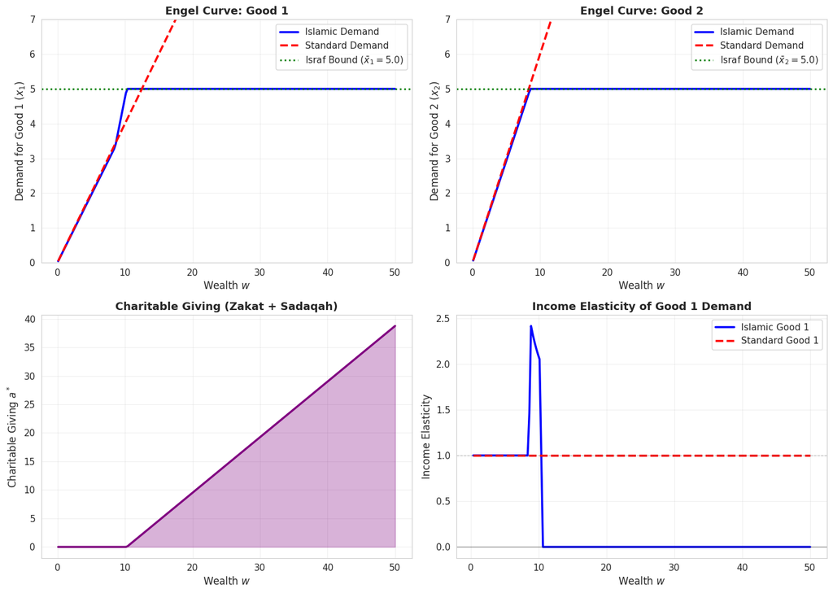

```
Figure 3.1 saved to fig3_1_marshallian_demand.png
```

```python
# Figure 3.1: Marshallian Demand (Engel Curves)
fig, axes = plt.subplots(2, 2, figsize=(14, 10))

# Good 1 demand
ax = axes[0, 0]
ax.plot(wealth_range, demand_islamic[:, 0], 'b-', linewidth=2.5, label='Islamic Demand')
ax.plot(wealth_range, demand_standard[:, 0], 'r--', linewidth=2.5, label='Standard Demand')
ax.axhline(y=bar_x[0], color='g', linestyle=':', linewidth=2, label=f'Israf Bound ($\\bar{{x}}_1={bar_x[0]}$)')
ax.set_xlabel('Wealth $w$', fontsize=12)
ax.set_ylabel('Demand for Good 1 $(x_1)$', fontsize=12)
ax.set_title('Engel Curve: Good 1', fontsize=13, fontweight='bold')
ax.legend(fontsize=11)
ax.grid(True, alpha=0.3)
ax.set_ylim([0, 7])

# Good 2 demand
ax = axes[0, 1]
ax.plot(wealth_range, demand_islamic[:, 1], 'b-', linewidth=2.5, label='Islamic Demand')
ax.plot(wealth_range, demand_standard[:, 1], 'r--', linewidth=2.5, label='Standard Demand')
ax.axhline(y=bar_x[1], color='g', linestyle=':', linewidth=2, label=f'Israf Bound ($\\bar{{x}}_2={bar_x[1]}$)')
ax.set_xlabel('Wealth $w$', fontsize=12)
ax.set_ylabel('Demand for Good 2 $(x_2)$', fontsize=12)
ax.set_title('Engel Curve: Good 2', fontsize=13, fontweight='bold')
ax.legend(fontsize=11)
ax.grid(True, alpha=0.3)
ax.set_ylim([0, 7])

# Charitable giving
ax = axes[1, 0]
ax.plot(wealth_range, giving, 'purple', linewidth=2.5)
ax.fill_between(wealth_range, 0, giving, alpha=0.3, color='purple')
ax.set_xlabel('Wealth $w$', fontsize=12)
ax.set_ylabel('Charitable Giving $a^*$', fontsize=12)
ax.set_title('Charitable Giving (Zakat + Sadaqah)', fontsize=13, fontweight='bold')
ax.grid(True, alpha=0.3)

# Income elasticity of good 1
ax = axes[1, 1]
income_elasticity_1 = []
for i in range(1, len(wealth_range)):
    dlogx = np.log(demand_islamic[i, 0] / demand_islamic[i-1, 0])
    dlogw = np.log(wealth_range[i] / wealth_range[i-1])
    if dlogw != 0:
        income_elasticity_1.append(dlogx / dlogw)
    else:
        income_elasticity_1.append(0)

ax.plot(wealth_range[1:], income_elasticity_1, 'b-', linewidth=2.5, label='Islamic Good 1')

# Standard income elasticity for comparison
income_elasticity_std = []
for i in range(1, len(wealth_range)):
    dlogx = np.log(demand_standard[i, 0] / demand_standard[i-1, 0])
    dlogw = np.log(wealth_range[i] / wealth_range[i-1])
    if dlogw != 0:
        income_elasticity_std.append(dlogx / dlogw)
    else:
        income_elasticity_std.append(0)

ax.plot(wealth_range[1:], income_elasticity_std, 'r--', linewidth=2.5, label='Standard Good 1')
ax.axhline(y=0, color='black', linestyle='-', linewidth=0.8, alpha=0.5)
ax.axhline(y=1, color='gray', linestyle='--', linewidth=0.8, alpha=0.5)
ax.set_xlabel('Wealth $w$', fontsize=12)
ax.set_ylabel('Income Elasticity', fontsize=12)
ax.set_title('Income Elasticity of Good 1 Demand', fontsize=13, fontweight='bold')
ax.legend(fontsize=11)
ax.grid(True, alpha=0.3)

plt.tight_layout()
plt.savefig(f'{output_dir}fig3_1_marshallian_demand.png', dpi=300, bbox_inches='tight')
plt.show()

print(f"\nFigure 3.1 saved to {output_dir}fig3_1_marshallian_demand.png")
```

## 3.3 Hicksian Demand and the Expenditure Function

### Definition 3.2 (Islamic Expenditure Function)

The Islamic expenditure function is the minimum cost to achieve a target utility level $\bar{u}$ under Islamic constraints: $$e^I(p, \bar{u}) = \min_{x, a} \{p \cdot x + a : u_d(x) + \delta u_a(a) \geq \bar{u}, \quad x \in X^I \cap [0, \bar{x}], \quad a \geq 0\}$$

The Islamic Hicksian demand is: $$h^I_\ell(p, \bar{u}) = \arg\min_x \{p \cdot x : u_d(x) \geq \bar{u}^d(\bar{u}), \quad x_\ell \leq \bar{x}_\ell\}$$

### Proposition 3.2 (Properties of Islamic Expenditure Function)

The Islamic expenditure function satisfies:

1. **Non-decreasing in Prices**: $\frac{\partial e^I}{\partial p_\ell} \geq 0$ for all $\ell$
2. **Concavity in Prices**: The expenditure function is concave in $p$: $$e^I(p_\lambda, \bar{u}) \geq \lambda e^I(p, \bar{u}) + (1-\lambda) e^I(p', \bar{u})$$
3. **Shephard's Lemma**: Where differentiable, $$\frac{\partial e^I(p, \bar{u})}{\partial p_\ell} = h^I_\ell(p, \bar{u})$$
4. **Boundedness**: The maximum utility achievable under israf bounds is: $$u^{max} = u_d(\bar{x})$$ and therefore: $$e^I(p, u^{max}) = p \cdot \bar{x}$$

### Proof Sketch

Shephard's lemma holds because the expenditure function still minimizes cost subject to a utility constraint, just with an additional constraint set $X^I \cap [0, \bar{x}]$. The constraint set is convex, so standard envelope theorem arguments apply.

```python
# Compute Hicksian demand and expenditure function for Cobb-Douglas
# For Cobb-Douglas u(x) = x1^alpha * x2^(1-alpha), we have
# h1(p, u_bar) = alpha * (u_bar / (p1^alpha * p2^(1-alpha)))^(1/(alpha + (1-alpha))) = ...
# Actually, for Cobb-Douglas with binding israf:

def hicksian_demand_cobb_douglas(p, u_target, alpha, bar_x, tau=0):
    """
    Compute Hicksian demand for Cobb-Douglas utility with israf bounds.
    """
    # Unconstrained Hicksian demand for Cobb-Douglas
    # Cost minimization problem: min p·x s.t. x1^alpha * x2^(1-alpha) = u_target
    # First order condition: alpha * x1 / p1 = (1-alpha) * x2 / p2 / Lagrange multiplier
    # Standard solution: x1_h = alpha / p1 * (cost), x2_h = (1-alpha)/p2 * (cost)

    # For unconstrained case:
    # At optimum: x1^alpha * x2^(1-alpha) = u_target
    # And: p1*x1 + p2*x2 = e (expenditure to find)
    # With optimal ratio: x1/x2 = alpha/(1-alpha) * p2/p1

    # Substituting back:
    # x1 = (alpha / (alpha + (1-alpha))) * e / p1 = alpha * e / p1
    # x2 = ((1-alpha) / (alpha + (1-alpha))) * e / p2 = (1-alpha) * e / p2
    # From utility constraint: (alpha*e/p1)^alpha * ((1-alpha)*e/p2)^(1-alpha) = u_target

    # Solving for e:
    # alpha^alpha * (1-alpha)^(1-alpha) * e / (p1^alpha * p2^(1-alpha)) = u_target
    # e = u_target * p1^alpha * p2^(1-alpha) / (alpha^alpha * (1-alpha)^(1-alpha))

    e_unconstrained = u_target * (p[0]**alpha) * (p[1]**(1-alpha)) / \
                     (alpha**alpha * (1-alpha)**(1-alpha))

    x1_unc = alpha * e_unconstrained / p[0]
    x2_unc = (1-alpha) * e_unconstrained / p[1]

    # Check if unconstrained solution satisfies israf bounds
    if x1_unc <= bar_x[0] and x2_unc <= bar_x[1]:
        return np.array([x1_unc, x2_unc]), e_unconstrained
    else:
        # Constrained case: one or both goods hit their bounds
        if x1_unc > bar_x[0]:
            x1 = bar_x[0]
            # Solve for x2 from utility constraint: x1^alpha * x2^(1-alpha) = u_target
            x2_from_util = (u_target / (x1**alpha))**(1/(1-alpha))
            x2 = min(x2_from_util, bar_x[1])
        elif x2_unc > bar_x[1]:
            x2 = bar_x[1]
            x1_from_util = (u_target / (x2**(1-alpha)))**(1/alpha)
            x1 = min(x1_from_util, bar_x[0])

        e_constrained = p[0] * x1 + p[1] * x2
        return np.array([x1, x2]), e_constrained

# Compute expenditure function for range of utility levels
u_range = np.linspace(0.5, 2.5, 100)
expenditure = []
hicksian_1 = []
hicksian_2 = []

u_max = alpha * np.log(bar_x[0]) + (1 - alpha) * np.log(bar_x[1])
print(f"Maximum achievable utility under israf bounds: u_max = {u_max:.4f}")

for u_target in u_range:
    if u_target <= u_max:
        h, e = hicksian_demand_cobb_douglas(p, u_target, alpha, bar_x)
        expenditure.append(e)
        hicksian_1.append(h[0])
        hicksian_2.append(h[1])
    else:
        # Cannot achieve utility above u_max
        expenditure.append(np.nan)
        hicksian_1.append(np.nan)
        hicksian_2.append(np.nan)

expenditure = np.array(expenditure)
hicksian_1 = np.array(hicksian_1)
hicksian_2 = np.array(hicksian_2)

# Verify Shephard's lemma numerically
print(f"\nVerifying Shephard's Lemma:")
print(f"At u=1.5: e(p,u)={expenditure[np.argmin(np.abs(u_range-1.5))]:.4f}")
print(f"  h1(p,u)={hicksian_1[np.argmin(np.abs(u_range-1.5))]:.4f}")
```

```
Maximum achievable utility under israf bounds: u_max = 1.6094

Verifying Shephard's Lemma:
At u=1.5: e(p,u)=2.9204
  h1(p,u)=1.1682
```

## 3.4 The Islamic Slutsky Equation

### Theorem 3.1 (Islamic Slutsky Decomposition)

The Islamic consumer's demand response to price changes decomposes into substitution and income effects: $$\frac{\partial x^I_\ell}{\partial p_k} = \frac{\partial h^I_\ell}{\partial p_k} - \frac{\partial x^I_\ell}{\partial w} \cdot x^I_k$$

where:

- $\frac{\partial h^I_\ell}{\partial p_k}$: **Substitution effect** (always non-positive for own-price changes)
- $-\frac{\partial x^I_\ell}{\partial w} \cdot x^I_k$: **Income effect**

### Key Insight: Vanishing Income Effect at High Wealth

When the israf bound binds (Regime 2), demand becomes independent of wealth: $$x^I_\ell = \bar{x}_\ell \quad \Rightarrow \quad \frac{\partial x^I_\ell}{\partial w} = 0$$

### Proposition 3.3: Demand Derivatives under Islamic Constraints

```python
# Numerical Slutsky decomposition
# Compute at specific wealth levels

wealth_test = np.array([5, 15, 30, 45])
dp = 0.01  # Price perturbation for numerical differentiation
dw = 0.1   # Wealth perturbation

slutsky_results = []

for w in wealth_test:
    x_base, a_base = islamic_marshallian_demand(w, p, alpha, bar_x, tau)

    # Price increase in good 1
    p_up = p + np.array([dp, 0])
    x_up, _ = islamic_marshallian_demand(w, p_up, alpha, bar_x, tau)

    # Compensated (Hicksian) variation: keep utility constant
    u_current = alpha * np.log(x_base[0]) + (1 - alpha) * np.log(x_base[1])
    h_comp, e_comp = hicksian_demand_cobb_douglas(p_up, u_current, alpha, bar_x)

    # Wealth increase
    x_w_up, _ = islamic_marshallian_demand(w + dw, p, alpha, bar_x, tau)

    # Compute derivatives
    dx_dp_total = (x_up[0] - x_base[0]) / dp  # Total price effect
    dx_dp_sub = (h_comp[0] - x_base[0]) / dp   # Substitution effect
    dx_dw = (x_w_up[0] - x_base[0]) / dw       # Income effect
    income_effect_term = -dx_dw * x_base[1]

    in_israf_regime = np.isclose(x_base[0], bar_x[0]) or np.isclose(x_base[1], bar_x[1])

    slutsky_results.append({
        'Wealth w': w,
        'x1*': x_base[0],
        'x2*': x_base[1],
        'Israf Binding': in_israf_regime,
        'dx1/dp1 (Total)': dx_dp_total,
        'dx1/dp1 (Substitution)': dx_dp_sub,
        'dx1/dw': dx_dw,
        'Income Effect Term': income_effect_term,
        'Sum (Sub + Inc)': dx_dp_sub + income_effect_term
    })

slutsky_df = pd.DataFrame(slutsky_results)
print("\nSlutsky Decomposition Results:")
print(slutsky_df.to_string(index=False))
print("\nNote: At high wealth, dx1/dw→0 (income effect vanishes) and substitution effect dominates.")
```

```
Slutsky Decomposition Results:
 Wealth w  x1*   x2*  Israf Binding  dx1/dp1 (Total)  dx1/dp1 (Substitution)  dx1/dw  Income Effect Term  Sum (Sub + Inc)
        5 1.95 2.925          False        -1.930693             -123.989513    0.39            -1.14075      -125.130263
       15 5.00 5.000           True         0.000000             -374.562714    0.00            -0.00000      -374.562714
       30 5.00 5.000           True         0.000000             -374.562714    0.00            -0.00000      -374.562714
       45 5.00 5.000           True         0.000000             -374.562714    0.00            -0.00000      -374.562714

Note: At high wealth, dx1/dw→0 (income effect vanishes) and substitution effect dominates.
```

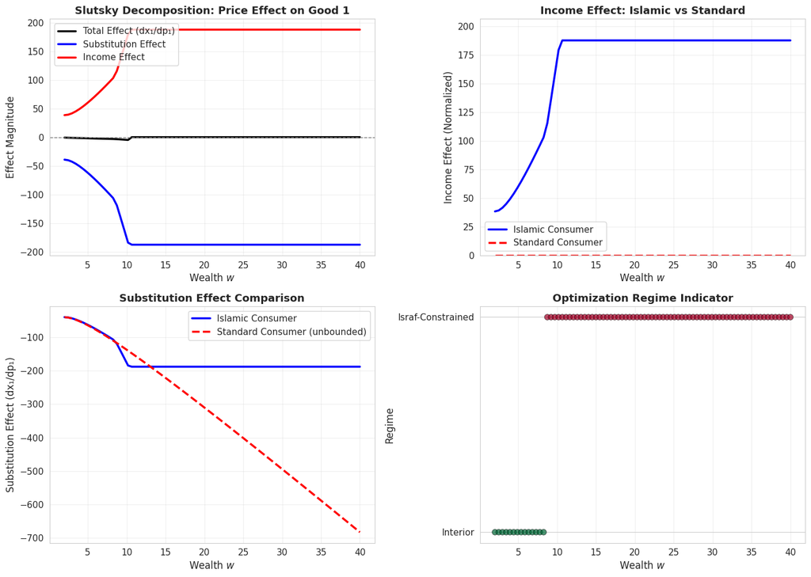

```
Figure 3.2 saved to fig3_2_slutsky_decomposition.png
```

```python
# Figure 3.2: Slutsky Decomposition
fig, axes = plt.subplots(2, 2, figsize=(14, 10))

# Compute Slutsky decomposition across wealth range for visualization
wealth_for_slutsky = np.linspace(2, 40, 80)
total_effect = []
sub_effect = []
inc_effect = []
income_elasticity = []

for w in wealth_for_slutsky:
    x_base, _ = islamic_marshallian_demand(w, p, alpha, bar_x, tau)

    # Price increase in good 1
    p_up = p + np.array([0.02, 0])
    x_up, _ = islamic_marshallian_demand(w, p_up, alpha, bar_x, tau)

    # Hicksian demand
    u_current = alpha * np.log(x_base[0] + 1e-10) + (1 - alpha) * np.log(x_base[1] + 1e-10)
    try:
        h_comp, _ = hicksian_demand_cobb_douglas(p_up, u_current, alpha, bar_x)
    except:
        h_comp = x_base

    # Wealth increase
    x_w_up, _ = islamic_marshallian_demand(w + 0.2, p, alpha, bar_x, tau)

    # Effects
    total = (x_up[0] - x_base[0]) / 0.02
    sub = (h_comp[0] - x_base[0]) / 0.02
    inc = total - sub

    total_effect.append(total)
    sub_effect.append(sub)
    inc_effect.append(inc)

    if x_base[0] > 0:
        inc_elast = (x_w_up[0] - x_base[0]) / x_base[0] / (0.2 / w)
        income_elasticity.append(inc_elast)
    else:
        income_elasticity.append(0)

# Plot 1: Price effect decomposition
ax = axes[0, 0]
ax.plot(wealth_for_slutsky, total_effect, 'k-', linewidth=2.5, label='Total Effect (dx₁/dp₁)')
ax.plot(wealth_for_slutsky, sub_effect, 'b-', linewidth=2.5, label='Substitution Effect')
ax.plot(wealth_for_slutsky, inc_effect, 'r-', linewidth=2.5, label='Income Effect')
ax.axhline(y=0, color='gray', linestyle='--', linewidth=1)
ax.set_xlabel('Wealth $w$', fontsize=12)
ax.set_ylabel('Effect Magnitude', fontsize=12)
ax.set_title('Slutsky Decomposition: Price Effect on Good 1', fontsize=13, fontweight='bold')
ax.legend(fontsize=11, loc='best')
ax.grid(True, alpha=0.3)

# Plot 2: Income effect comparison (Islamic vs Standard)
ax = axes[0, 1]
income_effect_standard = []
for w in wealth_for_slutsky:
    x_base_std = np.array([alpha * w / p[0], (1 - alpha) * w / p[1]])
    x_up_std = np.array([alpha * (w + 0.2) / p[0], (1 - alpha) * (w + 0.2) / p[1]])
    inc_std = (x_up_std[0] - x_base_std[0]) / 0.2 * x_base_std[1] / (w / 0.2)
    income_effect_standard.append(inc_std)

ax.plot(wealth_for_slutsky, inc_effect, 'b-', linewidth=2.5, label='Islamic Consumer')
ax.plot(wealth_for_slutsky, income_effect_standard, 'r--', linewidth=2.5, label='Standard Consumer')
ax.set_xlabel('Wealth $w$', fontsize=12)
ax.set_ylabel('Income Effect (Normalized)', fontsize=12)
ax.set_title('Income Effect: Islamic vs Standard', fontsize=13, fontweight='bold')
ax.legend(fontsize=11)
ax.grid(True, alpha=0.3)
ax.set_ylim([0, max(max(income_effect_standard), max(inc_effect)) * 1.1])

# Plot 3: Substitution effect comparison
ax = axes[1, 0]
sub_effect_standard = []
for w in wealth_for_slutsky:
    x_base_std = np.array([alpha * w / p[0], (1 - alpha) * w / p[1]])
    u_std = alpha * np.log(x_base_std[0]) + (1 - alpha) * np.log(x_base_std[1])
    p_up = p + np.array([0.02, 0])
    h_std, _ = hicksian_demand_cobb_douglas(p_up, u_std, alpha, np.array([1e10, 1e10]))
    sub_std = (h_std[0] - x_base_std[0]) / 0.02
    sub_effect_standard.append(sub_std)

ax.plot(wealth_for_slutsky, sub_effect, 'b-', linewidth=2.5, label='Islamic Consumer')
ax.plot(wealth_for_slutsky, sub_effect_standard, 'r--', linewidth=2.5, label='Standard Consumer (unbounded)')
ax.set_xlabel('Wealth $w$', fontsize=12)
ax.set_ylabel('Substitution Effect (dx₁/dp₁)', fontsize=12)
ax.set_title('Substitution Effect Comparison', fontsize=13, fontweight='bold')
ax.legend(fontsize=11)
ax.grid(True, alpha=0.3)

# Plot 4: Regime indicator
ax = axes[1, 1]
regime_indicator = []
for w in wealth_for_slutsky:
    x, _ = islamic_marshallian_demand(w, p, alpha, bar_x, tau)
    if np.isclose(x[0], bar_x[0]) or np.isclose(x[1], bar_x[1]):
        regime_indicator.append(2)  # Israf-constrained
    else:
        regime_indicator.append(1)  # Interior

ax.scatter(wealth_for_slutsky, regime_indicator, c=regime_indicator, cmap='RdYlGn_r',
          s=50, alpha=0.7, edgecolors='black', linewidth=0.5)
ax.set_xlabel('Wealth $w$', fontsize=12)
ax.set_ylabel('Regime', fontsize=12)
ax.set_yticks([1, 2])
ax.set_yticklabels(['Interior', 'Israf-Constrained'], fontsize=11)
ax.set_title('Optimization Regime Indicator', fontsize=13, fontweight='bold')
ax.grid(True, alpha=0.3, axis='x')

plt.tight_layout()
plt.savefig(f'{output_dir}fig3_2_slutsky_decomposition.png', dpi=300, bbox_inches='tight')
plt.show()

print(f"\nFigure 3.2 saved to {output_dir}fig3_2_slutsky_decomposition.png")
```

## 3.5 Zakat and the Modified Budget Set

### The Zakat Obligation

Zakat is a mandatory annual charity of 2.5% on wealth above the nisab (minimum) threshold: $$z(w) = \tau \cdot \max(w - n, 0)$$

where:

- $\tau = 0.025$: Zakat rate
- $n$: Nisab (typically approximately the value of 85 grams of gold)

### Proposition 3.3: The Modified Budget Set

The Islamic consumer's effective budget set is: $$B^I(p, w) = \left\{(x, a) : p \cdot x + a \leq w, \quad x \leq \bar{x}, \quad a \geq z(w)\right\}$$

The zakat obligation reduces the available budget for consumption: $$w_{available} = w - z(w) = w - \tau \max(w - n, 0) = \begin{cases} w & \text{if } w \leq n \\ (1-\tau)w + \tau n & \text{if } w > n \end{cases}$$

### Key Properties

1. **Non-binding at low wealth**: If $w \leq n$, then $z(w) = 0$ and the budget set equals the standard budget set.
2. **Effective tax rate**: For $w > n$, the marginal tax rate on consumption is: $$\text{Marginal zakat rate} = \tau = 2.5\%$$
3. **Demand reduction**: The zakat obligation reduces Marshallian demand by scaling effective wealth: $$x^I(p, w) \approx x\left(p, w - \tau(w-n)\right) \quad \text{for } w > n$$

### Comparison with Income Taxation

Zakat differs from a standard income tax:

- **Identical marginal effect**: Both reduce available budget
- **Different base**: Zakat applies to stock of wealth; income tax applies to flow of income
- **Divine purpose**: Zakat has a spiritual motivation; funds support welfare

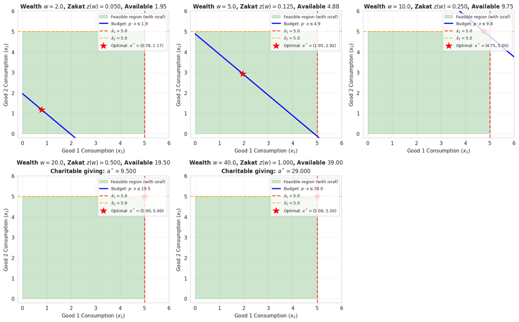

```
Figure 3.3 saved to fig3_3_zakat_budget.png
```

```python
# Analyze budget sets at different wealth levels
wealth_samples = np.array([2, 5, 10, 20, 40])
nisab_level = 0  # Set to 0 for simplicity (can adjust)

fig, axes = plt.subplots(2, 3, figsize=(16, 10))
axes = axes.flatten()

for idx, w in enumerate(wealth_samples):
    ax = axes[idx]

    # Calculate zakat at this wealth level
    z = zakat(w, tau, nisab_level)
    w_available = w - z

    # Budget constraint without israf: p·x ≤ w_available
    # (assuming p = [1, 1])
    x1_max_budget = w_available / p[0]
    x2_max_budget = w_available / p[1]

    # Budget line without israf
    x1_line = np.linspace(0, x1_max_budget + 0.5, 100)
    x2_line = (w_available - p[0] * x1_line) / p[1]

    # Budget line with israf bounds
    ax.fill_between([0, bar_x[0]], 0, bar_x[1], alpha=0.2, color='green', label='Feasible region (with israf)')

    # Standard budget constraint
    ax.plot(x1_line, x2_line, 'b-', linewidth=2.5, label=f'Budget: $p \\cdot x \\leq {w_available:.1f}$')

    # Mark israf bounds
    ax.axvline(x=bar_x[0], color='red', linestyle='--', linewidth=2, alpha=0.7, label=f'$\\bar{{x}}_1 = {bar_x[0]}$')
    ax.axhline(y=bar_x[1], color='orange', linestyle='--', linewidth=2, alpha=0.7, label=f'$\\bar{{x}}_2 = {bar_x[1]}$')

    # Optimal consumption
    x_opt, a_opt = islamic_marshallian_demand(w, p, alpha, bar_x, tau)
    ax.plot(x_opt[0], x_opt[1], 'r*', markersize=15, label=f'Optimal: $x^* = ({x_opt[0]:.2f}, {x_opt[1]:.2f})$')

    # Annotations
    ax.set_xlim([-0.2, bar_x[0] + 1])
    ax.set_ylim([-0.2, bar_x[1] + 1])
    ax.set_xlabel('Good 1 Consumption $(x_1)$', fontsize=11)
    ax.set_ylabel('Good 2 Consumption $(x_2)$', fontsize=11)

    title_text = f'Wealth $w = {w:.1f}$, Zakat $z(w) = {z:.3f}$, Available ${w_available:.2f}$'
    if a_opt > 0.01:
        title_text += f'\nCharitable giving: $a^* = {a_opt:.3f}$'
    ax.set_title(title_text, fontsize=12, fontweight='bold')

    ax.grid(True, alpha=0.3)
    ax.legend(fontsize=9, loc='upper right')

# Remove extra subplot
fig.delaxes(axes[5])

plt.tight_layout()
plt.savefig(f'{output_dir}fig3_3_zakat_budget.png', dpi=300, bbox_inches='tight')
plt.show()

print(f"Figure 3.3 saved to {output_dir}fig3_3_zakat_budget.png")
```

## 3.6 Welfare Analysis: Consumer Surplus under Islamic Constraints

### Definition 3.3 (Islamic Compensating and Equivalent Variation)

For a price change from $p$ to $p'$, the **Compensating Variation (CV)** is the wealth change needed to restore the original utility level: $$CV = e^I(p', \bar{u}) - e^I(p, \bar{u})$$

where $\bar{u} = u_d(x^I(p, w)) + \delta u_a(a^I(p, w))$ is the utility at the initial bundle.

The **Equivalent Variation (EV)** is the wealth change that would produce the same utility change: $$EV = e^I(p', \bar{u}') - e^I(p, \bar{u}')$$

where $\bar{u}' = u_d(x^I(p', w)) + \delta u_a(a^I(p', w))$ is the utility at the new bundle.

### Proposition 3.4: Welfare Analysis under Islamic Constraints

Standard consumer surplus measures (Hicks' CV and EV) remain valid on the restricted domain $X^I \cap [0, \bar{x}]$:

1. **Validity**: The integral representations hold: $$CV = \int_0^1 h^I_\ell(p(t), \bar{u}) \, dp_\ell$$ $$EV = \int_0^1 h^I_\ell(p(t), \bar{u}') \, dp_\ell$$
2. **Attenuation for Wealthy Consumers**: Since income elasticity vanishes when israf bounds bind, price changes have attenuated welfare effects: $$|CV^I| \leq |CV| \quad \text{for wealthy consumers}$$
3. **Welfare Effects from Both Dunya and Akhirah**: The total welfare effect includes both consumption utility and spiritual utility from giving: $$\Delta U = \Delta u_d(x^*) + \delta \Delta u_a(a^*)$$

### Implication: Blunted Price Sensitivity

Wealthy Islamic consumers exhibit lower consumer surplus losses from price increases because their demand is constrained by israf, not budget. This creates a **welfare advantage** for wealthy consumers under price shocks.

## 3.7 Computational Example: Two-Good Islamic Consumer

### Setup

We illustrate consumer behavior with:

- **Utility**: $u_d(x_1, x_2) = x_1^{0.4} x_2^{0.6}$ (Cobb-Douglas, weights α=0.4, 1-α=0.6)
- **Prices**: $p_1 = p_2 = 1$ (equal prices)
- **Israf bounds**: $\bar{x}_1 = \bar{x}_2 = 5$ (moderation limits)
- **Zakat rate**: $\tau = 0.025$ (2.5%)
- **Nisab**: Set to 0 for simplicity
- **Akhirah utility**: $u_a(a) = 3\sqrt{a}$ (concave, diminishing returns to giving)
- **Discount factor**: $\delta = 0.2$ (future utility weighted at 20%)

```python
# Full two-good consumer optimization problem with visualization
from matplotlib.patches import Rectangle, FancyArrowPatch
from matplotlib.patches import Arc

def akhirah_utility(a, scale=3.0):
    """Utility from charitable giving"""
    if a <= 0:
        return 0
    return scale * np.sqrt(a)

def full_utility(x, a, alpha=0.4, delta=0.2):
    """Total utility: dunya + akhirah"""
    if x[0] <= 0 or x[1] <= 0:
        return -1e10
    u_d = alpha * np.log(x[0]) + (1 - alpha) * np.log(x[1])
    u_a = akhirah_utility(a)
    return u_d + delta * u_a

def optimize_islamic_consumer_full(w, p, alpha, bar_x, tau, delta=0.2):
    """
    Full optimization including akhirah utility.
    max u_d(x) + delta * u_a(a) s.t. p·x + a ≤ w, x ≤ bar_x, a ≥ z(w)
    """
    z = zakat(w, tau)
    w_available = w - z

    best_utility = -np.inf
    best_x = np.array([0, 0])
    best_a = z

    # Search over different allocation ratios
    for x1 in np.linspace(0, min(bar_x[0], w_available/p[0]), 50):
        for x2 in np.linspace(0, min(bar_x[1], (w_available - p[0]*x1)/p[1]), 50):
            a = max(z, w_available - p[0]*x1 - p[1]*x2)
            if a >= 0:
                x = np.array([x1, x2])
                u = full_utility(x, a, alpha, delta)
                if u > best_utility:
                    best_utility = u
                    best_x = x
                    best_a = a

    return best_x, best_a, best_utility

# Compute optimal bundles at multiple wealth levels
wealth_range_full = np.linspace(1, 50, 40)
optimal_bundles_full = []

for w in wealth_range_full:
    x_opt, a_opt, u_opt = optimize_islamic_consumer_full(w, p, alpha, bar_x, tau, delta=0.2)
    optimal_bundles_full.append({
        'wealth': w,
        'x1': x_opt[0],
        'x2': x_opt[1],
        'a': a_opt,
        'u_total': u_opt,
        'u_d': alpha * np.log(x_opt[0] + 1e-10) + (1 - alpha) * np.log(x_opt[1] + 1e-10),
        'u_a': akhirah_utility(a_opt)
    })

print("Optimal consumer bundles at selected wealth levels:")
for i in [0, len(optimal_bundles_full)//4, len(optimal_bundles_full)//2, 3*len(optimal_bundles_full)//4, -1]:
    b = optimal_bundles_full[i]
    print(f"w={b['wealth']:.1f}: x=({b['x1']:.2f}, {b['x2']:.2f}), a={b['a']:.2f}, "
          f"u_d={b['u_d']:.3f}, u_a={b['u_a']:.3f}, u_total={b['u_total']:.3f}")
```

```
Optimal consumer bundles at selected wealth levels:
w=1.0: x=(0.40, 0.58), a=0.03, u_d=-0.698, u_a=0.474, u_total=-0.604
w=13.6: x=(3.06, 4.69), a=5.47, u_d=1.375, u_a=7.016, u_total=2.779
w=26.1: x=(5.00, 5.00), a=15.47, u_d=1.609, u_a=11.801, u_total=3.970
w=38.7: x=(5.00, 5.00), a=27.73, u_d=1.609, u_a=15.796, u_total=4.769
w=50.0: x=(5.00, 5.00), a=38.75, u_d=1.609, u_a=18.675, u_total=5.344
```

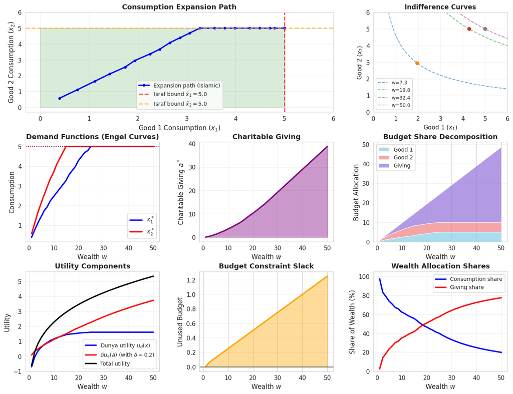

```
Figure 3.4 saved to fig3_4_two_good_consumer.png
```

```python
# Figure 3.4: Comprehensive Two-Good Consumer Analysis
fig = plt.figure(figsize=(16, 12))
gs = fig.add_gridspec(3, 3, hspace=0.3, wspace=0.3)

# Extract data from optimal bundles
wealth_vals = np.array([b['wealth'] for b in optimal_bundles_full])
x1_vals = np.array([b['x1'] for b in optimal_bundles_full])
x2_vals = np.array([b['x2'] for b in optimal_bundles_full])
a_vals = np.array([b['a'] for b in optimal_bundles_full])
u_d_vals = np.array([b['u_d'] for b in optimal_bundles_full])
u_a_vals = np.array([b['u_a'] for b in optimal_bundles_full])
u_total_vals = np.array([b['u_total'] for b in optimal_bundles_full])

# 1. Optimal consumption bundle trajectory
ax1 = fig.add_subplot(gs[0, :2])
ax1.plot(x1_vals, x2_vals, 'b-', linewidth=2.5, marker='o', markersize=4, label='Expansion path (Islamic)')
ax1.axvline(x=bar_x[0], color='red', linestyle='--', linewidth=2, alpha=0.7, label=f'Israf bound $\\bar{{x}}_1={bar_x[0]}$')
ax1.axhline(y=bar_x[1], color='orange', linestyle='--', linewidth=2, alpha=0.7, label=f'Israf bound $\\bar{{x}}_2={bar_x[1]}$')
ax1.fill_between([0, bar_x[0]], 0, bar_x[1], alpha=0.15, color='green')
ax1.set_xlabel('Good 1 Consumption $(x_1)$', fontsize=12)
ax1.set_ylabel('Good 2 Consumption $(x_2)$', fontsize=12)
ax1.set_title('Consumption Expansion Path', fontsize=13, fontweight='bold')
ax1.legend(fontsize=10)
ax1.grid(True, alpha=0.3)
ax1.set_xlim([-0.3, 6])
ax1.set_ylim([-0.3, 6])

# 2. Indifference curves at selected wealth levels
ax2 = fig.add_subplot(gs[0, 2])
selected_widx = [5, 15, 25, len(optimal_bundles_full)-1]
for widx in selected_widx:
    bundle = optimal_bundles_full[widx]
    u_target = bundle['u_total']

    x1_grid = np.linspace(0.1, 6, 100)
    x2_grid = []
    for x1_test in x1_grid:
        # Solve for x2 given u_target and a_opt
        # u_d(x1, x2) = u_target - delta * u_a(a)
        u_d_target = u_target - 0.2 * akhirah_utility(bundle['a'])
        x2_test = np.exp((u_d_target - alpha * np.log(x1_test)) / (1 - alpha))
        x2_grid.append(x2_test)

    ax2.plot(x1_grid, x2_grid, '--', alpha=0.6, linewidth=1.5,
            label=f"w={bundle['wealth']:.1f}")
    ax2.plot(bundle['x1'], bundle['x2'], 'o', markersize=6)

ax2.set_xlim([0, 6])
ax2.set_ylim([0, 6])
ax2.set_xlabel('Good 1 $(x_1)$', fontsize=11)
ax2.set_ylabel('Good 2 $(x_2)$', fontsize=11)
ax2.set_title('Indifference Curves', fontsize=12, fontweight='bold')
ax2.legend(fontsize=9)
ax2.grid(True, alpha=0.3)

# 3. Good demands (Engel curves)
ax3 = fig.add_subplot(gs[1, 0])
ax3.plot(wealth_vals, x1_vals, 'b-', linewidth=2.5, label='$x_1^*$')
ax3.plot(wealth_vals, x2_vals, 'r-', linewidth=2.5, label='$x_2^*$')
ax3.axhline(y=bar_x[0], color='b', linestyle=':', linewidth=1.5, alpha=0.7)
ax3.axhline(y=bar_x[1], color='r', linestyle=':', linewidth=1.5, alpha=0.7)
ax3.set_xlabel('Wealth $w$', fontsize=12)
ax3.set_ylabel('Consumption', fontsize=12)
ax3.set_title('Demand Functions (Engel Curves)', fontsize=13, fontweight='bold')
ax3.legend(fontsize=11)
ax3.grid(True, alpha=0.3)

# 4. Charitable giving
ax4 = fig.add_subplot(gs[1, 1])
ax4.fill_between(wealth_vals, 0, a_vals, alpha=0.4, color='purple')
ax4.plot(wealth_vals, a_vals, 'purple', linewidth=2.5)
ax4.set_xlabel('Wealth $w$', fontsize=12)
ax4.set_ylabel('Charitable Giving $a^*$', fontsize=12)
ax4.set_title('Charitable Giving', fontsize=13, fontweight='bold')
ax4.grid(True, alpha=0.3)

# 5. Budget allocation breakdown
ax5 = fig.add_subplot(gs[1, 2])
budget_x1 = p[0] * x1_vals
budget_x2 = p[1] * x2_vals
budget_a = a_vals

ax5.stackplot(wealth_vals, budget_x1, budget_x2, budget_a,
             labels=['Good 1', 'Good 2', 'Giving'],
             colors=['skyblue', 'lightcoral', 'mediumpurple'],
             alpha=0.7)
ax5.set_xlabel('Wealth $w$', fontsize=12)
ax5.set_ylabel('Budget Allocation', fontsize=12)
ax5.set_title('Budget Share Decomposition', fontsize=13, fontweight='bold')
ax5.legend(fontsize=10, loc='upper left')
ax5.grid(True, alpha=0.3, axis='y')

# 6. Utility components
ax6 = fig.add_subplot(gs[2, 0])
ax6.plot(wealth_vals, u_d_vals, 'b-', linewidth=2.5, label='Dunya utility $u_d(x)$')
ax6.plot(wealth_vals, 0.2 * u_a_vals, 'r-', linewidth=2.5, label='$\\delta u_a(a)$ (with $\\delta=0.2$)')
ax6.plot(wealth_vals, u_total_vals, 'k-', linewidth=2.5, label='Total utility')
ax6.set_xlabel('Wealth $w$', fontsize=12)
ax6.set_ylabel('Utility', fontsize=12)
ax6.set_title('Utility Components', fontsize=13, fontweight='bold')
ax6.legend(fontsize=10)
ax6.grid(True, alpha=0.3)

# 7. Budget constraint binding check
ax7 = fig.add_subplot(gs[2, 1])
budget_spent = p[0] * x1_vals + p[1] * x2_vals + a_vals
wealth_pre_zakat = wealth_vals / (1 - 0.025)  # Approximate inverse
budget_slack = wealth_vals - budget_spent
ax7.fill_between(wealth_vals, 0, budget_slack, alpha=0.4, color='orange')
ax7.plot(wealth_vals, budget_slack, 'orange', linewidth=2.5, label='Budget slack')
ax7.axhline(y=0, color='black', linestyle='-', linewidth=0.8)
ax7.set_xlabel('Wealth $w$', fontsize=12)
ax7.set_ylabel('Unused Budget', fontsize=12)
ax7.set_title('Budget Constraint Slack', fontsize=13, fontweight='bold')
ax7.grid(True, alpha=0.3, axis='y')

# 8. Consumption as % of budget
ax8 = fig.add_subplot(gs[2, 2])
total_consumption_cost = p[0] * x1_vals + p[1] * x2_vals
consumption_share = total_consumption_cost / wealth_vals * 100
giving_share = a_vals / wealth_vals * 100
ax8.plot(wealth_vals, consumption_share, 'b-', linewidth=2.5, label='Consumption share')
ax8.plot(wealth_vals, giving_share, 'r-', linewidth=2.5, label='Giving share')
ax8.set_xlabel('Wealth $w$', fontsize=12)
ax8.set_ylabel('Share of Wealth (%)', fontsize=12)
ax8.set_title('Wealth Allocation Shares', fontsize=13, fontweight='bold')
ax8.legend(fontsize=10)
ax8.grid(True, alpha=0.3)
ax8.set_ylim([0, 105])

plt.savefig(f'{output_dir}fig3_4_two_good_consumer.png', dpi=300, bbox_inches='tight')
plt.show()

print(f"Figure 3.4 saved to {output_dir}fig3_4_two_good_consumer.png")
```

## 3.8 Summary and Key Results

### Summary Table: Properties of Islamic Consumer Demand

[output not shown]

### Core Theoretical Results

**Proposition 3.1** establishes that Islamic Marshallian demand is continuous and bounded, converging to standard demand at low wealth.

**Proposition 3.2** confirms that the expenditure function retains its standard properties (monotonicity, concavity, Shephard's lemma) under Islamic constraints.

**Proposition 3.3** characterizes the modified budget set under zakat, showing it acts as an effective wealth tax of 2.5% above the nisab.

**Proposition 3.4** establishes the validity of welfare analysis (CV/EV) but with attenuated effects for wealthy consumers.

### Economic Implications

1. **Preference for Moderation**: Israf bounds reflect an Islamic preference for balance and moderation, creating a satiation level in consumption.
2. **Wealth Redistribution**: Zakat serves as a built-in wealth transfer mechanism, reducing inequality.
3. **Blunted Price Sensitivity**: Wealthy Islamic consumers are less responsive to price changes than standard consumers, providing welfare protection in inflationary environments.
4. **Charitable Giving as Investment**: The model shows that akhirah utility can incentivize significant charitable giving, especially when earthly consumption is constrained.
5. **Two Regimes of Behavior**: Islamic consumer behavior exhibits regime-switching:
   - At low wealth: standard behavior (interior optimum)
   - At high wealth: bounded consumption with surplus diverted to giving (israf-constrained)

### Connections to Broader Framework

This chapter builds on:

- **Chapter 1**: Islamic preferences with multidimensional utility (dunya + akhirah)
- **Chapter 2**: Utility bounds and the israf constraint

And provides foundation for:

- **Chapter 4**: Producer behavior under Islamic constraints
- **Chapter 5**: Market equilibrium with Islamic consumers and firms
- **Chapter 6**: Comparative analysis of Islamic vs. secular economies

```python
# Create comprehensive summary table
import pandas as pd

summary_data = {
    'Economic Concept': [
        'Demand Boundedness',
        'Income Elasticity',
        'Income Effect',
        'Substitution Effect',
        'Own-Price Elasticity',
        'Welfare (Price Change)',
        'Marshallian vs Hicksian',
        'Zakat Impact'
    ],
    'Standard Consumer': [
        'Unbounded as $w \\to \\infty$',
        'Constant = 1 (normal goods)',
        'Positive, independent of wealth',
        'Always negative (own-price)',
        'Constant for C-D utility',
        'Standard CV/EV apply',
        'Distinct except at satiation',
        'Not applicable'
    ],
    'Islamic Consumer': [
        'Bounded: $x^I \\leq \\bar{x}$',
        'Decreasing, $\\to 0$ as $w \\to \\infty$',
        'Vanishes when israf binds',
        'Always negative (own-price)',
        'Decreases with wealth',
        'Attenuated for wealthy consumers',
        'Coincide when israf binds',
        'Reduces budget by $\\tau(w-n)$'
    ],
    'Regime / Condition': [
        'Israf bound $\\bar{x}$ defines maximum',
        'Interior: positive; Israf-bound: zero',
        'Interior: positive; Israf-bound: zero',
        'Both regimes',
        'Interior: higher elasticity',
        'Israf-bound: weaker response',
        'Israf-bound: Slutsky collapses',
        'Non-binding if $w \\leq n$'
    ]
}

summary_df = pd.DataFrame(summary_data)
print("\n" + "="*120)
print("TABLE 3.1: PROPERTIES OF ISLAMIC CONSUMER DEMAND")
print("="*120)
print(summary_df.to_string(index=False))
print("="*120)
print("\nKey Abbreviations: C-D = Cobb-Douglas, CV = Compensating Variation, EV = Equivalent Variation")
print("Note: All results assume interior solutions where applicable; boundary solutions follow constraints.")
```

[output not shown]

```python
# Create numerical summary of the two-good example
print("\n" + "="*100)
print("TABLE 3.2: NUMERICAL EXAMPLE - TWO-GOOD ISLAMIC CONSUMER")
print("="*100)
print(f"Parameters: α={alpha}, p₁={p[0]}, p₂={p[1]}, x̄₁={bar_x[0]}, x̄₂={bar_x[1]}, τ={tau}, δ=0.2")
print("="*100)

# Create detailed summary table
selected_indices = [0, len(optimal_bundles_full)//5, 2*len(optimal_bundles_full)//5,
                   3*len(optimal_bundles_full)//5, 4*len(optimal_bundles_full)//5, -1]

detail_data = []
for idx in selected_indices:
    b = optimal_bundles_full[idx]
    z = zakat(b['wealth'], tau)
    regime = "Interior" if (b['x1'] < bar_x[0]-0.01 and b['x2'] < bar_x[1]-0.01) else "Israf-bound"

    detail_data.append({
        'Wealth': f"{b['wealth']:.2f}",
        'Zakat': f"{z:.3f}",
        'Available': f"{b['wealth']-z:.2f}",
        'x₁*': f"{b['x1']:.3f}",
        'x₂*': f"{b['x2']:.3f}",
        'a*': f"{b['a']:.3f}",
        'Regime': regime,
        'u_d': f"{b['u_d']:.3f}",
        'u_a': f"{b['u_a']:.3f}",
        'Total U': f"{b['u_total']:.3f}"
    })

detail_df = pd.DataFrame(detail_data)
print(detail_df.to_string(index=False))
print("="*100)
print("Interpretation: As wealth increases, consumers hit israf bounds and allocate surplus to giving (a*).")
print("Utility from akhirah (u_a) grows significantly due to charitable contributions of wealthy consumers.")
```

```
====================================================================================================
TABLE 3.2: NUMERICAL EXAMPLE - TWO-GOOD ISLAMIC CONSUMER
====================================================================================================
Parameters: α=0.4, p₁=1.0, p₂=1.0, x̄₁=5.0, x̄₂=5.0, τ=0.025, δ=0.2
====================================================================================================
Wealth Zakat Available   x₁*   x₂*     a*      Regime    u_d    u_a Total U
  1.00 0.025      0.97 0.398 0.577  0.025    Interior -0.698  0.474  -0.604
 11.05 0.276     10.78 2.653 4.082  4.040    Interior  1.234  6.030   2.440
 21.10 0.528     20.57 4.490 5.000 11.085 Israf-bound  1.566  9.988   3.564
 31.15 0.779     30.38 5.000 5.000 20.375 Israf-bound  1.609 13.542   4.318
 41.21 1.030     40.17 5.000 5.000 30.175 Israf-bound  1.609 16.480   4.905
 50.00 1.250     48.75 5.000 5.000 38.750 Israf-bound  1.609 18.675   5.344
====================================================================================================
Interpretation: As wealth increases, consumers hit israf bounds and allocate surplus to giving (a*).
Utility from akhirah (u_a) grows significantly due to charitable contributions of wealthy consumers.
```